# Diazotrophic community associations with *Racomitrium lanuginosum* genetic groups

## 4.2 PERMANOVA

We evaluate how the variation is affected by the habitat and genetic group (genotype).

```r
# PERMANOVA
permanova_nifH_gen <- adonis2(t(ps_nifH_gbs_norm_GMPR@otu_table) ~ ps_nifH_gbs_norm_GMPR@sam_data$Habitat * ps_nifH_gbs_norm_GMPR@sam_data$Genotype, permutations = perm, method = "bray",strata = ps_nifH_gbs_norm_GMPR@sam_data$Plot)
permanova_nifH_gen
```

|  | Df | SumOfSqs | R2 | F | Pr(>F) |
| --- | --- | --- | --- | --- | --- |
| ps_nifH_gbs_norm_GMPR@sam_data$Habitat | 1 | 0.9867921 | 0.05442520 | 2.8976327 | 0.9515242 |
| ps_nifH_gbs_norm_GMPR@sam_data$Genotype | 1 | 0.2082050 | 0.01148327 | 0.6113765 | 0.9520240 |
| ps_nifH_gbs_norm_GMPR@sam_data$Habitat:ps_nifH_gbs_norm_GMPR@sam_data$Genotype | 1 | 0.2491576 | 0.01374195 | 0.7316305 | 0.8195902 |
| Residual | 49 | 16.6870051 | 0.92034957 | NA | NA |
| Total | 52 | 18.1311597 | 1.00000000 | NA | NA |

```r
# Check variance heterogenity or dispersion among groups
set.seed(123)
BC_nifH_beta_disper_1 <- betadisper(bray_dist_nifH,ps_nifH_gbs_norm_GMPR@sam_data$Gen_Habitat)
permutest(BC_nifH_beta_disper_1)
```

```
##
## Permutation test for homogeneity of multivariate dispersions
## Permutation: free
## Number of permutations: 999
##
## Response: Distances
##           Df  Sum Sq   Mean Sq      F N.Perm Pr(>F)
## Groups     3 0.02258 0.0075282 0.5839    999  0.619
## Residuals 49 0.63172 0.0128923
```

```r
# The test indicate that the there is not enough proofs
# to confirm that the homogeneity of multivariate dispersion between groups differ
```

# 5. Differentially abundant bacteria

We can identify groups that are more abundant between habitats or genetic groups. In this case, we use ANCOMBC-2 to identify differential abundant diazotrophic genera with bias corrections.

We use the non-rarefied count because ANCOMBC-2 normalize the data before run the analysis.

```r
#if (!require("BiocManager", quietly = TRUE))
#  install.packages("BiocManager")
#BiocManager::install("ANCOMBC")

library(ANCOMBC)

# Check the number of samples per category
table(nifH_gbs@sam_data$Habitat,nifH_gbs@sam_data$Genotype)
```

```
##
##                 AB CD
##   Forest tundra 12 19
##   Shrub tundra   7 15
```

```r
# Check the number of sequences per sample
sum_seq <- rowSums(t(nifH_gbs@otu_table))
sort(sum_seq)
```

```
## JC2798 JC2790 JC3085 JC2959 JC2943 JC2945 JC2796 JC3087 JC2956 JC2801 JC2795
##   1369   1436   2186   2459   2625   2671   2689   2772   2811   2960   2979
## JC2962 JC3089 JC2793 JC2938 JC3086 JC2955 JC2950 JC2803 JC2806 JC3212 JC2937
##   3016   3138   3205   3336   3455   3805   3867   4796   4867   5046   5225
## JC2805 JC3210 JC2797 JC2804 JC2939 JC2960 JC2794 JC2929 JC2953 JC2930 JC3088
##   5303   5509   5834   6204   6289   6638   6701   6817   6931   7691   7727
## JC2940 JC2944 JC2961 JC2963 JC2951 JC2926 JC2949 JC2792 JC2948 JC2933 JC2947
##   7942   8255   8363   8480   8518   8699   8798   8923   8927   9133   9799
## JC2802 JC2807 JC3090 JC2958 JC2791 JC2800 JC2927 JC2952 JC3214
##  10475  10906  11249  11300  13125  13524  13575  14466  18143
```

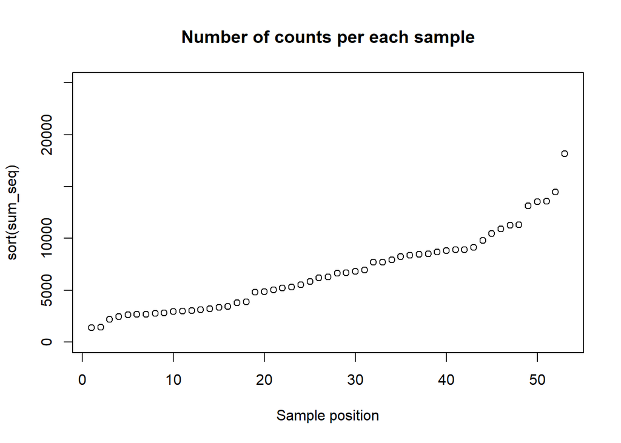

```r
plot(sort(sum_seq), ylim=c(0,25000), main=c("Number of counts per each sample"), xlab=c("Sample position"))
```

```r
# Run ANCOMBC
library(ANCOMBC)

set.seed(123)
out_nifH = ancombc2(
  data = nifH_gbs,
  tax_level = "Genus",
  fix_formula = "Habitat + Genotype",
  group = "Genotype",
  p_adj_method = "fdr",
  global = TRUE,
  verbose = TRUE
)
```

```
## Obtaining initial estimates ...
```

```
## Estimating sample-specific biases ...
```

```
## Sensitivity analysis for pseudo-count addition to 0s: ...
```

```
## ANCOM-BC2 primary results ...
```

```r
# prv_cut = 0.05, In this case, we already filtered ASVs by prevalence (previous step in Escolastico-Ortiz et al. 2023. Symbiosis.).
# Library size cut less than 1000 reads.
# If we applied the struc_zero we will find taxa that occur differentially based on presence/absence.

# Create a new data frame with the results
res_nifH_gbs <- out_nifH$res

# By default, ANCOM-BC2 does not add pseudo-counts to zero counts, which can
# result in NAs in the bias-corrected log abundances. Users have the option to
# either leave the NAs as they are or replace them with zeros.
# This replacement is equivalent to adding pseudo-counts of ones to the zero counts.

# The p-values from ANCOM-BC2, both with and without sensitivity analysis, exhibit a nearly uniform distribution.
# Notably, enabling sensitivity analysis significantly reduces the number of significant p-values, thereby decreasing the risk of false positives.
```

Now, we create a function that allow to plot the results.

```r
extract_differential_abundance <- function(df_Group, res_data, taxon_col, lfc_col, q_col, grouping_var,
                                        passed_col = NULL) {

  # Create another data frame with the relevant grouping results
  df_group_res <- res_data %>%
    dplyr::select({{taxon_col}}, contains({{grouping_var}}), {{passed_col}})

# Add association based on significance, using custom group names
  df_group_res <- df_group_res %>%
    dplyr::mutate(
      association = dplyr::case_when(
        !!rlang::sym(q_col) < 0.05 & !!rlang::sym(lfc_col) > 0 ~ "Enriched",
        !!rlang::sym(q_col) < 0.05 & !!rlang::sym(lfc_col) < 0 ~ "Depleted",
        TRUE ~ "Not significant"
      ),
      font = ifelse(!is.null(passed_col) & !!rlang::sym(passed_col), "bold", "plain"),
      color = ifelse(!is.null(passed_col) & !!rlang::sym(passed_col), "blue", "black"),
    )

  # Extract differentially abundant groups
  results_sig <- df_group_res[df_group_res[[q_col]] < 0.05,]
  table(results_sig$association)

  # Order the data
  results_sig <- results_sig[order(results_sig$association, results_sig[[lfc_col]]),]
  desired_order <- results_sig[[taxon_col]]

  # Convert 'Genera' (taxon_col) to a factor with the specified order
  results_sig[[taxon_col]] <- factor(results_sig[[taxon_col]], levels = desired_order)

# Return the results as a list
  return(list(df_group_res = df_group_res, results_sig = results_sig))
}

# Example usage:
# extract_differential_abundance(df_Genotype, res_16S_gbs, "taxon", "lfc_GenotypeCD", "q_GenotypeCD", "Genotype","AB","CD", passed_col= "passed_ss_GenotypeCD")
```

We use the results of our function to plot the differentially abundant taxa.

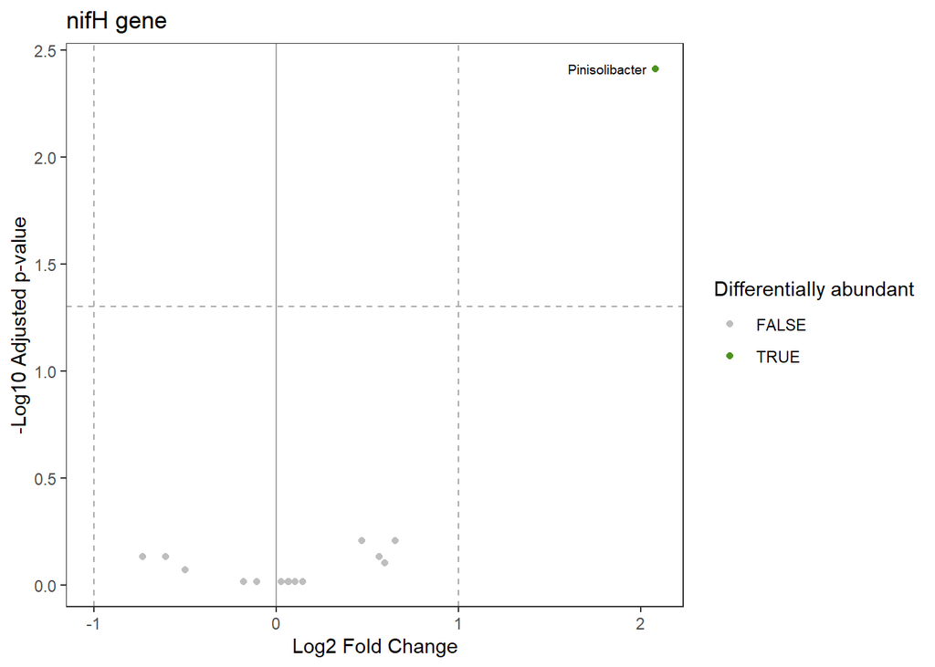

```r
# Run Script to produce the data
Results_ANCOMBC2_nifH <- extract_differential_abundance(df_Genotype, res_nifH_gbs, "taxon", "lfc_GenotypeCD", "q_GenotypeCD", "Genotype", passed_col= "passed_ss_GenotypeCD")

# Store only the significant taxa data
Result_total_ANCOMBC2_nifH <- Results_ANCOMBC2_nifH$df_group_res
Result_sig_ANCOMBC2_nifH <- Results_ANCOMBC2_nifH$results_sig

# Plot the significant differential abundant taxa
library(ggrepel)  # For better label positioning

# Extract the labels for the significant taxa
sig_labels_nifH <- ifelse(Result_total_ANCOMBC2_nifH$diff_GenotypeCD == TRUE,Result_total_ANCOMBC2_nifH$taxon, NA)

# Create plot for significant abundant taxa
Plot_significant_taxa_nifH <- ggplot(Result_total_ANCOMBC2_nifH, aes(x = lfc_GenotypeCD, y = -log10(q_GenotypeCD))) +
  geom_point(aes(color = diff_GenotypeCD)) +
  scale_color_manual(values = c("grey", "#4d9221")) +
  theme( panel.grid.major = element_blank(),panel.grid.minor = element_blank()) +
  labs(x = "Log2 Fold Change", y = "-Log10 Adjusted p-value",color= "Differentially abundant", title= "nifH gene") +
  geom_vline(xintercept = 0, color = "darkgrey", linewidth = 0.5) +
  geom_vline(xintercept = -1, linetype = "dashed", color = "darkgrey", linewidth = 0.5) +  # LFC = -1
  geom_vline(xintercept = 1, linetype = "dashed", color = "darkgrey", linewidth = 0.5) +   # LFC = 1
  geom_hline(yintercept = -log10(0.05), linetype = "dashed", color = "darkgrey", linewidth = 0.5) +  # P-value = 0.05 threshold
  geom_text_repel(aes(label = sig_labels_nifH), na.rm = TRUE,size = 2.5)  # Only labels significant genes

Plot_significant_taxa_nifH
```

```r
# ggsave("Figure_Significant_DA_taxa_Genotype_nifH.tiff", units="mm", width=200, height=150, dpi=150, compression = "lzw")

# THERE IS ONLY ONE DIFFERENTIALLY ABUNDANT GENUS: Pinisolibacter in the Genetic group CD
# The genus did not passed the sensitivity analyses: passed_ss_GenotypeCD = FALSE

Result_total_ANCOMBC2_nifH
```

| taxon | lfc_GenotypeCD | se_GenotypeCD | W_GenotypeCD | p_GenotypeCD | q_GenotypeCD | diff_GenotypeCD | passed_ss_GenotypeCD | association | font | color |
| --- | --- | --- | --- | --- | --- | --- | --- | --- | --- | --- |
| Rhodomicrobium | -0.10579893 | 0.7043427 | -0.1502095 | 0.8812858464 | 0.960238523 | FALSE | TRUE | Not significant | bold | blue |
| Dolichospermum | -0.50102912 | 0.6193279 | -0.8089884 | 0.4227785777 | 0.845557155 | FALSE | FALSE | Not significant | plain | black |
| Nostoc | 0.02775756 | 0.5539338 | 0.0501099 | 0.9602385232 | 0.960238523 | FALSE | TRUE | Not significant | bold | blue |
| Trichormus | 0.59304089 | 0.6180352 | 0.9595585 | 0.3444720286 | 0.787364637 | FALSE | TRUE | Not significant | bold | blue |
| Iningainema | -0.10844268 | 0.6110719 | -0.1774630 | 0.8599591468 | 0.960238523 | FALSE | TRUE | Not significant | bold | blue |
| Azorhizobium | -0.73113590 | 0.5567410 | -1.3132424 | 0.1957584425 | 0.734013270 | FALSE | TRUE | Not significant | bold | blue |
| Calothrix | 0.06503494 | 0.5628286 | 0.1155502 | 0.9088054774 | 0.960238523 | FALSE | TRUE | Not significant | bold | blue |
| Fischerella | 0.06663401 | 0.5203640 | 0.1280527 | 0.8987042953 | 0.960238523 | FALSE | TRUE | Not significant | bold | blue |
| Anabaena | -0.60549821 | 0.5014271 | -1.2075499 | 0.2346828836 | 0.734013270 | FALSE | FALSE | Not significant | plain | black |
| Mastigocladus | 0.56297469 | 0.5074349 | 1.1094521 | 0.2752549764 | 0.734013270 | FALSE | TRUE | Not significant | bold | blue |

[output cut: 6 more lines]

```r
# Plot log2 fold changes

# Plot_lfc <- ggplot(Results_ANCOMBC2_nifH, aes(x= lfc_GenotypeCD, y = taxon, color = association)) +
#   geom_point() +
#   geom_segment(aes(x = 0, xend = lfc_GenotypeCD, y = taxon, yend = taxon)) +
#   geom_vline(xintercept = 0, size = 0.3) +
#   xlab("log2FoldChange") + ylab(NULL) +
#   theme_classic() +
#   scale_color_manual(values = c("AB" = "gray", "CD" = "#363636")) +  # Custom colors
#   theme(
#     legend.title = element_blank(),
#     axis.text.y = element_text(face = Result_sig_ANCOMBC2$font,color = Result_sig_ANCOMBC2$color))
#
# Plot_lfc

# ggsave("Figure_3_ANCOMBC2__Genotype_nifH.tiff", units="mm", width=230, height=120, dpi=150, compression = "lzw")
```

*THERE IS ONLY ONE DIFFERENTIALLY ABUNDANT GENUS:* Pinisolibacter in the Genetic group CD. The genus did not passed the sensitivity analysis.

# Supplementary analyses

We can merge the plot results for both 16S and nifH into combined plots

```r
Microbial_profiles <-  ggarrange(BarPlot_bacteria_gbs_genus  + rremove ("xlab") , BarPlot_nifH_GBS_genus + rremove ("xlab"),nrow=2, ncol=1, align = "v", labels = c("a","c"))
Microbial_NMDS <- ggarrange(NMDS.BC_Bacteria_gbs, NMDS_bray_nifH_gen , nrow=2, ncol=1, align = "v", common.legend = TRUE, legend = "right", labels = c("b","d"))
Genotype_microbiome_covariation <- ggarrange(Microbial_profiles,  Microbial_NMDS , nrow=1, ncol=2, align = "hv", widths = c(2, 1))
# ggsave("Figure_X_Genotype_microbiome_covariation_figure.tiff", units="mm", width=430, height=250, dpi=300, compression = "lzw")


Microbial_profiles_2 <- ggarrange(BarPlot_bacteria_gbs_genus_Habitat_genotype + rremove ("xlab") + rremove ("x.text"), BarPlot_nifH_GBS_genus_Genotype,nrow=2, ncol=1, align = "v",labels = c("a","c"))
Genotype_microbiome_covariation_2 <- Genotype_microbiome_covariation <- ggarrange(Microbial_profiles_2,  Microbial_NMDS , nrow=1, ncol=2, align = "h")

# ggsave("Figure_X2_Genotype_microbiome_covariation_pooled_figure.tiff", units="mm", width=250, height=250, dpi=300, compression = "lzw")
# ggsave("Figure_X3_Genotype_microbiome_covariation_pooled_figure.tiff", units="mm", width=250, height=150, dpi=300, compression = "lzw")
```